# EmmanuelObiekwe_Practical_Lab1

NAME : CHINONSO EMMANUEL OBIEKWE STUDENT NO.: 8877022

FRAMING THE PROBLEM The objective of the report is to develop univariate linear regression models to predict median house values in Carlifornia using three independent variables: median income, population, and number of households.

IMPORT LIBRARIES

```python
import pandas as pd
import numpy as np
import seaborn as sns
import matplotlib.pyplot as plt
from sklearn.linear_model import LinearRegression
from sklearn.metrics import mean_squared_error, mean_absolute_error
```

IMPORT THE CSV FILES

```python
import pandas as pd

df = pd.read_csv(r"/Users/owner/Downloads/housing.csv")
```

VIEW THE FIRST FIVE ROWS HEAD() AND LAST FIVE ROWS TAIL() OF THE DATA

```python
df.head(5)
```

|  | longitude | latitude | housing_median_age | total_rooms | total_bedrooms | population | households | median_income | median_house_value | ocean_proximity |
| --- | --- | --- | --- | --- | --- | --- | --- | --- | --- | --- |
| 0 | -122.23 | 37.88 | 41.0 | 880.0 | 129.0 | 322.0 | 126.0 | 8.3252 | 452600.0 | NEAR BAY |
| 1 | -122.22 | 37.86 | 21.0 | 7099.0 | 1106.0 | 2401.0 | 1138.0 | 8.3014 | 358500.0 | NEAR BAY |
| 2 | -122.24 | 37.85 | 52.0 | 1467.0 | 190.0 | 496.0 | 177.0 | 7.2574 | 352100.0 | NEAR BAY |
| 3 | -122.25 | 37.85 | 52.0 | 1274.0 | 235.0 | 558.0 | 219.0 | 5.6431 | 341300.0 | NEAR BAY |
| 4 | -122.25 | 37.85 | 52.0 | 1627.0 | 280.0 | 565.0 | 259.0 | 3.8462 | 342200.0 | NEAR BAY |

```python
df.tail(5)
```

|  | longitude | latitude | housing_median_age | total_rooms | total_bedrooms | population | households | median_income | median_house_value | ocean_proximity |
| --- | --- | --- | --- | --- | --- | --- | --- | --- | --- | --- |
| 20635 | -121.09 | 39.48 | 25.0 | 1665.0 | 374.0 | 845.0 | 330.0 | 1.5603 | 78100.0 | INLAND |
| 20636 | -121.21 | 39.49 | 18.0 | 697.0 | 150.0 | 356.0 | 114.0 | 2.5568 | 77100.0 | INLAND |
| 20637 | -121.22 | 39.43 | 17.0 | 2254.0 | 485.0 | 1007.0 | 433.0 | 1.7000 | 92300.0 | INLAND |
| 20638 | -121.32 | 39.43 | 18.0 | 1860.0 | 409.0 | 741.0 | 349.0 | 1.8672 | 84700.0 | INLAND |
| 20639 | -121.24 | 39.37 | 16.0 | 2785.0 | 616.0 | 1387.0 | 530.0 | 2.3886 | 89400.0 | INLAND |

GET THE DIMENSION OF THE DATA

```python
df.shape
```

```
(20640, 10)
```

GATHER THE INFORMATION OF THE DATA INCLUDING COLUMNS, DATATYPES AND NULLS

```python
df.info()
```

```
<class 'pandas.core.frame.DataFrame'>
RangeIndex: 20640 entries, 0 to 20639
Data columns (total 10 columns):
 #   Column              Non-Null Count  Dtype
---  ------              --------------  -----
 0   longitude           20640 non-null  float64
 1   latitude            20640 non-null  float64
 2   housing_median_age  20640 non-null  float64
 3   total_rooms         20640 non-null  float64
 4   total_bedrooms      20433 non-null  float64
 5   population          20640 non-null  float64
 6   households          20640 non-null  float64
 7   median_income       20640 non-null  float64
 8   median_house_value  20640 non-null  float64
 9   ocean_proximity     20640 non-null  object
dtypes: float64(9), object(1)
memory usage: 1.6+ MB
```

```python
# Selecting relevant columns

df = df[['median_house_value', 'median_income', 'population', 'households']]
```

GET THE NUMBER SUMMARY OF THE DATA OF THE CONTINOUS VARIABLE

```python
# Exploratory Data Analysis (EDA)
summary = df.describe().T
summary
```

|  | count | mean | std | min | 25% | 50% | 75% | max |
| --- | --- | --- | --- | --- | --- | --- | --- | --- |
| median_house_value | 20640.0 | 206855.816909 | 115395.615874 | 14999.0000 | 119600.0000 | 179700.0000 | 264725.00000 | 500001.0000 |
| median_income | 20640.0 | 3.870671 | 1.899822 | 0.4999 | 2.5634 | 3.5348 | 4.74325 | 15.0001 |
| population | 20640.0 | 1425.476744 | 1132.462122 | 3.0000 | 787.0000 | 1166.0000 | 1725.00000 | 35682.0000 |
| households | 20640.0 | 499.539680 | 382.329753 | 1.0000 | 280.0000 | 409.0000 | 605.00000 | 6082.0000 |

```
<function matplotlib.pyplot.show(close=None, block=None)>
```

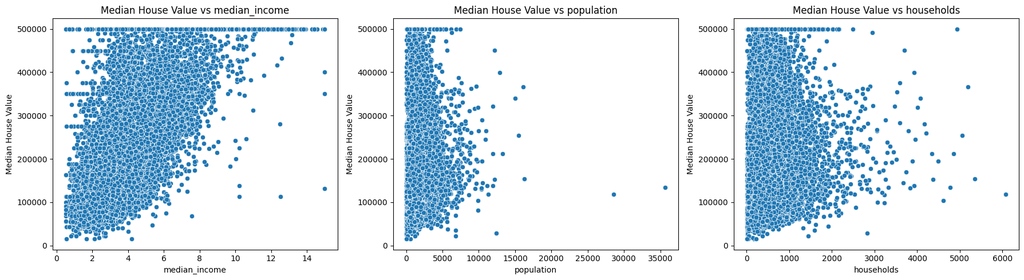

```python
import matplotlib.pyplot as plt
import seaborn as sns

# Scatter plots
fig, axes = plt.subplots(1, 3, figsize=(18, 5))
variables = ['median_income', 'population', 'households']

def scatter_plot(var, ax):
    sns.scatterplot(x=df[var], y=df['median_house_value'], ax=ax)
    ax.set_title(f'Median House Value vs {var}')
    ax.set_xlabel(var)
    ax.set_ylabel('Median House Value')

for var, ax in zip(variables, axes):
    scatter_plot(var, ax)

plt.tight_layout()
plt.show
```

RUNNING THREE LINEAR REGRESSION MODELS

```python
from sklearn.linear_model import LinearRegression
from sklearn.metrics import mean_squared_error, mean_absolute_error

def train_model(independent_var):
    X = df[[independent_var]]
    y = df['median_house_value']
    model = LinearRegression()
    model.fit(X, y)
    predictions = model.predict(X)

    mse = mean_squared_error(y, predictions)
    mae = mean_absolute_error(y, predictions)
    intercept = model.intercept_
    slope = model.coef_[0]

    return model, predictions, mse, mae, intercept, slope

# Train models
results = {}
for var in variables:
    results[var] = train_model(var)
```

DISPLAYING RESULTS

```python
results_df = pd.DataFrame({
  'Variable': variables,
  'Intercept': [results[var][1] for var in variables],
  'Slope': [results[var][2] for var in variables],
  'MSE': [results[var][3] for var in variables],
  'MAE': [results[var][3] for var in variables],
})
print(results_df)
```

```
        Variable                                          Intercept  \
0  median_income  [393027.7300788949, 392033.0364678897, 348400....
1     population  [209627.47768284727, 204405.5436644225, 209190...
2     households  [199432.54683194202, 219543.7952894536, 200446...

          Slope           MSE           MAE
0  7.011312e+09  62625.933791  62625.933791
1  1.330741e+10  91153.820095  91153.820095
2  1.325778e+10  90802.743243  90802.743243
```

```
median_income has scalar predictions.
population has scalar predictions.
households has scalar predictions.
```

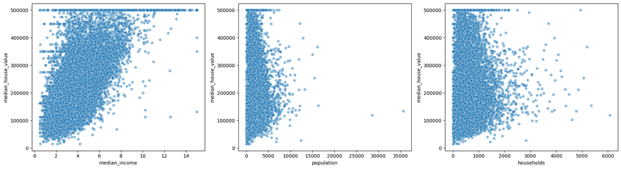

```python
import numpy as np
import seaborn as sns
import matplotlib.pyplot as plt

variables = ['median_income', 'population', 'households']

# Create subplots
fig, axes = plt.subplots(1, 3, figsize=(18, 5))

for var, ax in zip(variables, axes):
    # Scatter plot
    sns.scatterplot(x=df[var], y=df['median_house_value'], ax=ax, alpha=0.5)

    # Check if results exist
    if var not in results or len(results[var]) < 6:
        print(f"Skipping {var} due to missing predictions.")
        continue

    # Ensure y_pred is a valid array
    if isinstance(results[var][5], (list, np.ndarray)):
        y_pred = np.array(results[var][5])
    else:
        print(f"{var} has scalar predictions.")
        continue

    # Sort values for correct regression line plotting
    sorted_indices = df[var].argsort()
    X_sorted = df[var].iloc[sorted_indices]
    y_pred_sorted = y_pred[sorted_indices]

    # Plot regression line
    sns.lineplot(x=X_sorted, y=y_pred_sorted, ax=ax, color='red')

    # Add regression metrics as a text box
    ax.text(0.05, 0.9,
            f'Intercept: {results[var][1]:.2f}\nSlope: {results[var][2]:.2f}\n'
            f'MSE: {results[var][3]:.2f}\nMAE: {results[var][4]:.2f}',
            transform=ax.transAxes, fontsize=12, bbox=dict(facecolor='white', alpha=0.6))

    ax.set_title(f'Median House Value vs. {var}')

plt.tight_layout()
plt.show()
```

CONCLUSION After fitting three univariate linear regression models to predict median house value using median income, population and number of households, I compared their performance using Mean Squared Error (MSE) and Mean Absolute Error (MAE)

COMPARISON

1. Median Income vs Median House Value : This model showed the strongest correlation with the lowest MSE and MAE.
2. Population vs Median House Value: This model performed significantly worse with a high error and weak linear relationship.
3. Number of households vs Median House Value: This model was slightly better than population but still performed worse than median income.

ADDITIONAL INSIGHTS Median Income is the most influential predictor. Higher income levels are directly correlated with higher house values, confirming that affordability and purchasing power drive real estate prices.